# M2.855_20211_PEC1-Solucion

## 2.2 Análisis exploratorio de los datos

En este ejercicio vamos a explorar la relación de algunos de los atributos numéricos con la variable respuesta ("Diagnosis"), tanto gráficamente como cuantitativamente y analizaremos las distintas correlaciones. Para empezar, seleccionad los 4 atributos que queréis explorar. Si habéis usado los nombres de columnas proporcionados por sklearn, una lista de posibles nombres de atributos serían:

```python
feats_to_explore = ['mean radius', 'mean texture', 'mean smoothness', 'mean symmetry']
```

**Ejercicio:** utilizando una librería gráfica, como por ejemplo "matplotlib", realizad un gráfico del histograma de valores para cada uno de los atributos seleccionados, separados por los valores de clase de la respuesta ("Diagnosis"). La finalidad es observar como se distribuye cada uno de los atributos en función del valor de clase que toman, para poder identificar de forma visual y rápida si algunos atributos permiten diferenciar de forma clara los diferentes diagnósticos de los tumores.

Sugerencia: podéis usar el parámetro "alpha" en los gráficos para que se aprecien los tres histogramas.

**Solución:**

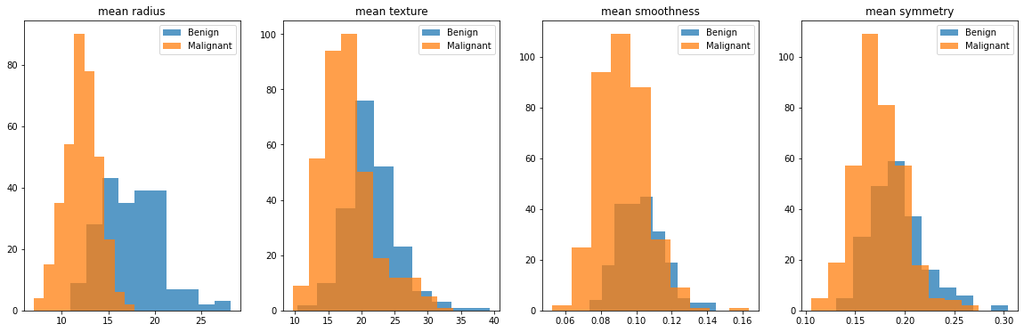

```python
# preparación de la figura:
fig, axs = plt.subplots(nrows=1, ncols=len(feats_to_explore), figsize=(20,6))

# un gráfico por atributo en feats_to_explore:
for i, featName in enumerate(feats_to_explore):
    # un histograma por tipo de diagnosis:
    for diag in df_brcan["Classes"].unique():
        axs[i].hist(df_brcan.loc[df_brcan["Classes"]==diag, featName], alpha=0.75, label=diag)
        axs[i].set_title(featName)
        axs[i].legend(loc='upper right')
```

**Análisis:** mirando los gráficos, ¿qué atributos te parece que tienen valores claramente diferentes para diagnósticos benignos y malignos? ¿Qué atributos no?

**Ejercicio:** para cada uno de los atributos representados en el ejercicio anterior, mostrad la media y la desviación estándard para cada valor de clase de la respuesta. La finalidad es verificar numéricamente las diferencias identificadas anteriormente de forma visual.

**Solución:**

```python
# para cada atributo en la lista feats_to_explore, calculamos la media y desviación estándard
# en los casos de diagnosis='malignant' y diagnosis='beningn':
for featName in feats_to_explore:
    print("***",featName,"***")
    for diag in df_brcan["Classes"].unique():
        mean = df_brcan.loc[df_brcan["Classes"]==diag, featName].mean()
        std = df_brcan.loc[df_brcan["Classes"]==diag, featName].std()
        print("mean '%s' for diagnosis='%s': %.3f +- %.3f" % (featName, diag, mean, std))
```

```
*** mean radius ***
mean 'mean radius' for diagnosis='Benign': 17.463 +- 3.204
mean 'mean radius' for diagnosis='Malignant': 12.147 +- 1.781
*** mean texture ***
mean 'mean texture' for diagnosis='Benign': 21.605 +- 3.779
mean 'mean texture' for diagnosis='Malignant': 17.915 +- 3.995
*** mean smoothness ***
mean 'mean smoothness' for diagnosis='Benign': 0.103 +- 0.013
mean 'mean smoothness' for diagnosis='Malignant': 0.092 +- 0.013
*** mean symmetry ***
mean 'mean symmetry' for diagnosis='Benign': 0.193 +- 0.028
mean 'mean symmetry' for diagnosis='Malignant': 0.174 +- 0.025
```

**Análisis:** mirando a los valores medios y desviaciones estándard calculadas, ¿te parecen significativas las diferencias para diagnósticos benignos y malignos?

**Solución:** la comparación de valores medios y desviaciones estándard nos permite confirmar que el "mean radius" es el único atributo cuyos valores medios para diagnósticos benigno y maligno son claramente diferentes, incluso teniendo en cuenta las desviaciones estándard.

**Ejercicio:** calculad y mostrad la correlación entre todas las variables del conjunto de datos.

**Solución:**

```python
corr_all = df_brcan.corr()
corr_all.style.background_gradient(cmap='coolwarm').set_precision(2)
```

|  | mean radius | mean texture | mean perimeter | mean area | mean smoothness | mean compactness | mean concavity | mean concave points | mean symmetry | mean fractal dimension | radius error | texture error | perimeter error | area error | smoothness error | compactness error | concavity error | concave points error | symmetry error | fractal dimension error | worst radius | worst texture | worst perimeter | worst area | worst smoothness | worst compactness | worst concavity | worst concave points | worst symmetry | … |
| --- | --- | --- | --- | --- | --- | --- | --- | --- | --- | --- | --- | --- | --- | --- | --- | --- | --- | --- | --- | --- | --- | --- | --- | --- | --- | --- | --- | --- | --- | --- |
| mean radius | 1.00 | 0.32 | 1.00 | 0.99 | 0.17 | 0.51 | 0.68 | 0.82 | 0.15 | -0.31 | 0.68 | -0.10 | 0.67 | 0.74 | -0.22 | 0.21 | 0.19 | 0.38 | -0.10 | -0.04 | 0.97 | 0.30 | 0.97 | 0.94 | 0.12 | 0.41 | 0.53 | 0.74 | 0.16 | … |
| mean texture | 0.32 | 1.00 | 0.33 | 0.32 | -0.02 | 0.24 | 0.30 | 0.29 | 0.07 | -0.08 | 0.28 | 0.39 | 0.28 | 0.26 | 0.01 | 0.19 | 0.14 | 0.16 | 0.01 | 0.05 | 0.35 | 0.91 | 0.36 | 0.34 | 0.08 | 0.28 | 0.30 | 0.30 | 0.11 | … |
| mean perimeter | 1.00 | 0.33 | 1.00 | 0.99 | 0.21 | 0.56 | 0.72 | 0.85 | 0.18 | -0.26 | 0.69 | -0.09 | 0.69 | 0.74 | -0.20 | 0.25 | 0.23 | 0.41 | -0.08 | -0.01 | 0.97 | 0.30 | 0.97 | 0.94 | 0.15 | 0.46 | 0.56 | 0.77 | 0.19 | … |
| mean area | 0.99 | 0.32 | 0.99 | 1.00 | 0.18 | 0.50 | 0.69 | 0.82 | 0.15 | -0.28 | 0.73 | -0.07 | 0.73 | 0.80 | -0.17 | 0.21 | 0.21 | 0.37 | -0.07 | -0.02 | 0.96 | 0.29 | 0.96 | 0.96 | 0.12 | 0.39 | 0.51 | 0.72 | 0.14 | … |
| mean smoothness | 0.17 | -0.02 | 0.21 | 0.18 | 1.00 | 0.66 | 0.52 | 0.55 | 0.56 | 0.58 | 0.30 | 0.07 | 0.30 | 0.25 | 0.33 | 0.32 | 0.25 | 0.38 | 0.20 | 0.28 | 0.21 | 0.04 | 0.24 | 0.21 | 0.81 | 0.47 | 0.43 | 0.50 | 0.39 | … |
| mean compactness | 0.51 | 0.24 | 0.56 | 0.50 | 0.66 | 1.00 | 0.88 | 0.83 | 0.60 | 0.57 | 0.50 | 0.05 | 0.55 | 0.46 | 0.14 | 0.74 | 0.57 | 0.64 | 0.23 | 0.51 | 0.54 | 0.25 | 0.59 | 0.51 | 0.57 | 0.87 | 0.82 | 0.82 | 0.51 | … |
| mean concavity | 0.68 | 0.30 | 0.72 | 0.69 | 0.52 | 0.88 | 1.00 | 0.92 | 0.50 | 0.34 | 0.63 | 0.08 | 0.66 | 0.62 | 0.10 | 0.67 | 0.69 | 0.68 | 0.18 | 0.45 | 0.69 | 0.30 | 0.73 | 0.68 | 0.45 | 0.75 | 0.88 | 0.86 | 0.41 | … |
| mean concave points | 0.82 | 0.29 | 0.85 | 0.82 | 0.55 | 0.83 | 0.92 | 1.00 | 0.46 | 0.17 | 0.70 | 0.02 | 0.71 | 0.69 | 0.03 | 0.49 | 0.44 | 0.62 | 0.10 | 0.26 | 0.83 | 0.29 | 0.86 | 0.81 | 0.45 | 0.67 | 0.75 | 0.91 | 0.38 | … |
| mean symmetry | 0.15 | 0.07 | 0.18 | 0.15 | 0.56 | 0.60 | 0.50 | 0.46 | 1.00 | 0.48 | 0.30 | 0.13 | 0.31 | 0.22 | 0.19 | 0.42 | 0.34 | 0.39 | 0.45 | 0.33 | 0.19 | 0.09 | 0.22 | 0.18 | 0.43 | 0.47 | 0.43 | 0.43 | 0.70 | … |
| mean fractal dimension | -0.31 | -0.08 | -0.26 | -0.28 | 0.58 | 0.57 | 0.34 | 0.17 | 0.48 | 1.00 | 0.00 | 0.16 | 0.04 | -0.09 | 0.40 | 0.56 | 0.45 | 0.34 | 0.35 | 0.69 | -0.25 | -0.05 | -0.21 | -0.23 | 0.50 | 0.46 | 0.35 | 0.18 | 0.33 | … |
| radius error | 0.68 | 0.28 | 0.69 | 0.73 | 0.30 | 0.50 | 0.63 | 0.70 | 0.30 | 0.00 | 1.00 | 0.21 | 0.97 | 0.95 | 0.16 | 0.36 | 0.33 | 0.51 | 0.24 | 0.23 | 0.72 | 0.19 | 0.72 | 0.75 | 0.14 | 0.29 | 0.38 | 0.53 | 0.09 | … |
| texture error | -0.10 | 0.39 | -0.09 | -0.07 | 0.07 | 0.05 | 0.08 | 0.02 | 0.13 | 0.16 | 0.21 | 1.00 | 0.22 | 0.11 | 0.40 | 0.23 | 0.19 | 0.23 | 0.41 | 0.28 | -0.11 | 0.41 | -0.10 | -0.08 | -0.07 | -0.09 | -0.07 | -0.12 | -0.13 | … |
| perimeter error | 0.67 | 0.28 | 0.69 | 0.73 | 0.30 | 0.55 | 0.66 | 0.71 | 0.31 | 0.04 | 0.97 | 0.22 | 1.00 | 0.94 | 0.15 | 0.42 | 0.36 | 0.56 | 0.27 | 0.24 | 0.70 | 0.20 | 0.72 | 0.73 | 0.13 | 0.34 | 0.42 | 0.55 | 0.11 | … |
| area error | 0.74 | 0.26 | 0.74 | 0.80 | 0.25 | 0.46 | 0.62 | 0.69 | 0.22 | -0.09 | 0.95 | 0.11 | 0.94 | 1.00 | 0.08 | 0.28 | 0.27 | 0.42 | 0.13 | 0.13 | 0.76 | 0.20 | 0.76 | 0.81 | 0.13 | 0.28 | 0.39 | 0.54 | 0.07 | … |
| smoothness error | -0.22 | 0.01 | -0.20 | -0.17 | 0.33 | 0.14 | 0.10 | 0.03 | 0.19 | 0.40 | 0.16 | 0.40 | 0.15 | 0.08 | 1.00 | 0.34 | 0.27 | 0.33 | 0.41 | 0.43 | -0.23 | -0.07 | -0.22 | -0.18 | 0.31 | -0.06 | -0.06 | -0.10 | -0.11 | … |
| compactness error | 0.21 | 0.19 | 0.25 | 0.21 | 0.32 | 0.74 | 0.67 | 0.49 | 0.42 | 0.56 | 0.36 | 0.23 | 0.42 | 0.28 | 0.34 | 1.00 | 0.80 | 0.74 | 0.39 | 0.80 | 0.20 | 0.14 | 0.26 | 0.20 | 0.23 | 0.68 | 0.64 | 0.48 | 0.28 | … |
| concavity error | 0.19 | 0.14 | 0.23 | 0.21 | 0.25 | 0.57 | 0.69 | 0.44 | 0.34 | 0.45 | 0.33 | 0.19 | 0.36 | 0.27 | 0.27 | 0.80 | 1.00 | 0.77 | 0.31 | 0.73 | 0.19 | 0.10 | 0.23 | 0.19 | 0.17 | 0.48 | 0.66 | 0.44 | 0.20 | … |
| concave points error | 0.38 | 0.16 | 0.41 | 0.37 | 0.38 | 0.64 | 0.68 | 0.62 | 0.39 | 0.34 | 0.51 | 0.23 | 0.56 | 0.42 | 0.33 | 0.74 | 0.77 | 1.00 | 0.31 | 0.61 | 0.36 | 0.09 | 0.39 | 0.34 | 0.22 | 0.45 | 0.55 | 0.60 | 0.14 | … |
| symmetry error | -0.10 | 0.01 | -0.08 | -0.07 | 0.20 | 0.23 | 0.18 | 0.10 | 0.45 | 0.35 | 0.24 | 0.41 | 0.27 | 0.13 | 0.41 | 0.39 | 0.31 | 0.31 | 1.00 | 0.37 | -0.13 | -0.08 | -0.10 | -0.11 | -0.01 | 0.06 | 0.04 | -0.03 | 0.39 | … |
| fractal dimension error | -0.04 | 0.05 | -0.01 | -0.02 | 0.28 | 0.51 | 0.45 | 0.26 | 0.33 | 0.69 | 0.23 | 0.28 | 0.24 | 0.13 | 0.43 | 0.80 | 0.73 | 0.61 | 0.37 | 1.00 | -0.04 | -0.00 | -0.00 | -0.02 | 0.17 | 0.39 | 0.38 | 0.22 | 0.11 | … |
| worst radius | 0.97 | 0.35 | 0.97 | 0.96 | 0.21 | 0.54 | 0.69 | 0.83 | 0.19 | -0.25 | 0.72 | -0.11 | 0.70 | 0.76 | -0.23 | 0.20 | 0.19 | 0.36 | -0.13 | -0.04 | 1.00 | 0.36 | 0.99 | 0.98 | 0.22 | 0.48 | 0.57 | 0.79 | 0.24 | … |
| worst texture | 0.30 | 0.91 | 0.30 | 0.29 | 0.04 | 0.25 | 0.30 | 0.29 | 0.09 | -0.05 | 0.19 | 0.41 | 0.20 | 0.20 | -0.07 | 0.14 | 0.10 | 0.09 | -0.08 | -0.00 | 0.36 | 1.00 | 0.37 | 0.35 | 0.23 | 0.36 | 0.37 | 0.36 | 0.23 | … |
| worst perimeter | 0.97 | 0.36 | 0.97 | 0.96 | 0.24 | 0.59 | 0.73 | 0.86 | 0.22 | -0.21 | 0.72 | -0.10 | 0.72 | 0.76 | -0.22 | 0.26 | 0.23 | 0.39 | -0.10 | -0.00 | 0.99 | 0.37 | 1.00 | 0.98 | 0.24 | 0.53 | 0.62 | 0.82 | 0.27 | … |
| worst area | 0.94 | 0.34 | 0.94 | 0.96 | 0.21 | 0.51 | 0.68 | 0.81 | 0.18 | -0.23 | 0.75 | -0.08 | 0.73 | 0.81 | -0.18 | 0.20 | 0.19 | 0.34 | -0.11 | -0.02 | 0.98 | 0.35 | 0.98 | 1.00 | 0.21 | 0.44 | 0.54 | 0.75 | 0.21 | … |
| worst smoothness | 0.12 | 0.08 | 0.15 | 0.12 | 0.81 | 0.57 | 0.45 | 0.45 | 0.43 | 0.50 | 0.14 | -0.07 | 0.13 | 0.13 | 0.31 | 0.23 | 0.17 | 0.22 | -0.01 | 0.17 | 0.22 | 0.23 | 0.24 | 0.21 | 1.00 | 0.57 | 0.52 | 0.55 | 0.49 | … |
| worst compactness | 0.41 | 0.28 | 0.46 | 0.39 | 0.47 | 0.87 | 0.75 | 0.67 | 0.47 | 0.46 | 0.29 | -0.09 | 0.34 | 0.28 | -0.06 | 0.68 | 0.48 | 0.45 | 0.06 | 0.39 | 0.48 | 0.36 | 0.53 | 0.44 | 0.57 | 1.00 | 0.89 | 0.80 | 0.61 | … |
| worst concavity | 0.53 | 0.30 | 0.56 | 0.51 | 0.43 | 0.82 | 0.88 | 0.75 | 0.43 | 0.35 | 0.38 | -0.07 | 0.42 | 0.39 | -0.06 | 0.64 | 0.66 | 0.55 | 0.04 | 0.38 | 0.57 | 0.37 | 0.62 | 0.54 | 0.52 | 0.89 | 1.00 | 0.86 | 0.53 | … |
| worst concave points | 0.74 | 0.30 | 0.77 | 0.72 | 0.50 | 0.82 | 0.86 | 0.91 | 0.43 | 0.18 | 0.53 | -0.12 | 0.55 | 0.54 | -0.10 | 0.48 | 0.44 | 0.60 | -0.03 | 0.22 | 0.79 | 0.36 | 0.82 | 0.75 | 0.55 | 0.80 | 0.86 | 1.00 | 0.50 | … |
| worst symmetry | 0.16 | 0.11 | 0.19 | 0.14 | 0.39 | 0.51 | 0.41 | 0.38 | 0.70 | 0.33 | 0.09 | -0.13 | 0.11 | 0.07 | -0.11 | 0.28 | 0.20 | 0.14 | 0.39 | 0.11 | 0.24 | 0.23 | 0.27 | 0.21 | 0.49 | 0.61 | 0.53 | 0.50 | 1.00 | … |
| worst fractal dimension | 0.01 | 0.12 | 0.05 | 0.00 | 0.50 | 0.69 | 0.51 | 0.37 | 0.44 | 0.77 | 0.05 | -0.05 | 0.09 | 0.02 | 0.10 | 0.59 | 0.44 | 0.31 | 0.08 | 0.59 | 0.09 | 0.22 | 0.14 | 0.08 | 0.62 | 0.81 | 0.69 | 0.51 | 0.54 | … |
| Diagnosis | -0.73 | -0.42 | -0.74 | -0.71 | -0.36 | -0.60 | -0.70 | -0.78 | -0.33 | 0.01 | -0.57 | 0.01 | -0.56 | -0.55 | 0.07 | -0.29 | -0.25 | -0.41 | 0.01 | -0.08 | -0.78 | -0.46 | -0.78 | -0.73 | -0.42 | -0.59 | -0.66 | -0.79 | -0.42 | … |

**Ejercicio:** representad gráficamente las relaciones entre todas las parejas de las variables "mean" del conjunto de datos. La finalidad de este ejercicio es poder observar y analizar las correlaciones de manera gráfica entre algunas de las variables.

Sugerencia: podéis usar la función "pairplot" de la librería 'seaborn'.

**Solución:**

```python
#Create a subset with only the mean values and check the correlation among the different variables
df_brcan_mean = df_brcan.filter(regex='mean')
df_brcan_mean.head()
```

|  | mean radius | mean texture | mean perimeter | mean area | mean smoothness | mean compactness | mean concavity | mean concave points | mean symmetry | mean fractal dimension |
| --- | --- | --- | --- | --- | --- | --- | --- | --- | --- | --- |
| 0 | 17.99 | 10.38 | 122.80 | 1001.0 | 0.11840 | 0.27760 | 0.3001 | 0.14710 | 0.2419 | 0.07871 |
| 1 | 20.57 | 17.77 | 132.90 | 1326.0 | 0.08474 | 0.07864 | 0.0869 | 0.07017 | 0.1812 | 0.05667 |
| 2 | 19.69 | 21.25 | 130.00 | 1203.0 | 0.10960 | 0.15990 | 0.1974 | 0.12790 | 0.2069 | 0.05999 |
| 3 | 11.42 | 20.38 | 77.58 | 386.1 | 0.14250 | 0.28390 | 0.2414 | 0.10520 | 0.2597 | 0.09744 |
| 4 | 20.29 | 14.34 | 135.10 | 1297.0 | 0.10030 | 0.13280 | 0.1980 | 0.10430 | 0.1809 | 0.05883 |

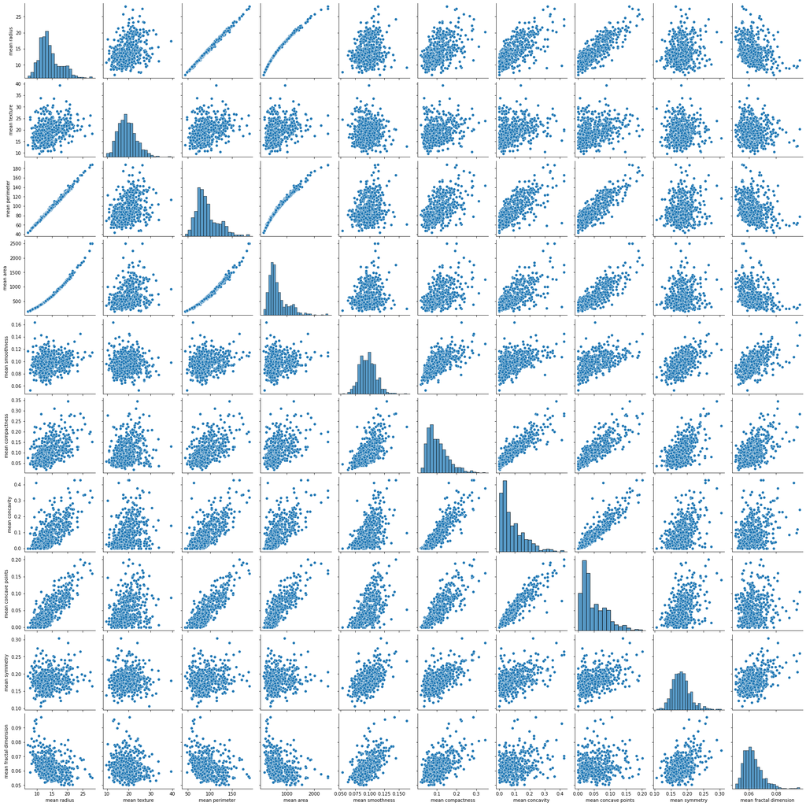

```python
sns.pairplot(df_brcan_mean)
```

**Ejercicio:** determinad cuáles son las variables con una correlación superior al 90% y cread un nuevo conjunto de datos (dataframe) eliminando estas variables.

**Solución:**

```python
# Selecciona el triángulo superior de la matriz de correlación
upper = corr_all.where(np.triu(np.ones(corr_all.shape), k=1).astype(np.bool))

# Encuentra el índice de las columnas con correlación superior a 0.90
highCorr = [column for column in upper.columns if any(upper[column] > 0.9)]
highCorr
```

```
['mean perimeter',
 'mean area',
 'mean concave points',
 'perimeter error',
 'area error',
 'worst radius',
 'worst texture',
 'worst perimeter',
 'worst area',
 'worst concave points']
```

```python
#Crea un nuevo dataset quitando las variables con alta correlación
df_brcan_reduced = df_brcan.drop(df_brcan[highCorr], axis=1)
```

**Análisis:** mirando las correlaciones, ¿qué variables son las que tienen una correlación más fuerte y han sido eliminadas? ¿Qué efecto puede tener en el resultado final el hecho de elminarlas o no?

**Solución:** cuando hay variables fuertemente correlacionadas significa que de un modo u otro la información que proporcionan es redundante (p.ej.: perímetro, radio, área). Así, dadas dos variables con fuerte correlación, si se elimina una de ellas se puede evitar la generación de un sesgo en la predicción de la información que contienen. Eso es importante tenerlo presente cuando se extraen conclusiones sobre la importancia o el peso de una variable en el resultado final (diagnóstico o predicción).

**Bonus:**  
- ¿Qué test estadístico podrías usar para comparar las distribuciones de los valores de los atributos cuando los diagnósticos son benignos o malignos? Úsalo para evaluar qué atributos (de entre todos los del conjunto de datos) tienen valores más parecidos en tumores benignos y malignos. Interpreta el resultado.

**Solución:**  
- La prueba de Kolmogorov-Smirnov nos permite evaluar si dos conjuntos de datos fueron obtenidos de la misma distribución subyacente. En la implementación de la prueba que podéis encontrar en la siguiente celda vemos que los 3 atributos para los que es más difícil descartar que los valores para diagnóstico benigno y maligno provienen de la misma distribución son 'symmetry error', 'texture error' y 'smoothness error'. Tiene sentido que los errores estándard en las mediciones del tumor no dependan tan fuertemente del tipo de tumor.

```python
from scipy import stats
import operator
# Kolmogorov-Smirnov statistic on 2 samples
# the hypothesis is that the distributions are the same. A small p-value indicates that the hypothesis can be rejected.
d_pv = {}
for featN in l_feat_names:
    d_pv[featN] = stats.ks_2samp(df_brcan.loc[df_brcan["Classes"]=="Malignant",featN], df_brcan.loc[df_brcan["Classes"]=="Benign", featN])[1]
# the highest p-values are those for more similar distributions. Here we sort our dict by values (ascending),
# and take the last 3 (highest p-values):
print("atributs amb distribucions de valors més semblants en els casos benigne i maligne:",
     sorted(d_pv.items(), key=operator.itemgetter(1))[-3:])
```

```
atributs amb distribucions de valors més semblants en els casos benigne i maligne: [('symmetry error', 0.03203447374991797), ('texture error', 0.13502697104761463), ('smoothness error', 0.23394487162202626)]
```

# 3. Reducción de dimensionalidad (3 puntos)

En este ejercicio deberéis aplicar métodos de reducción de dimensionalidad al conjunto original de datos. El objetivo es reducir el conjunto de atributos a un nuevo conjunto con menos dimensiones.

**Ejercicio:** aplicad el método de reducción de dimensionalidad Principal Component Analysis (PCA) para reducir a 2 dimensiones:  
- El conjunto de datos original  
- El conjunto de datos al cual se le han extraído las variables fuertemente correlacionadas NOTA: Tened cuidado y no incluyáis la variable objetivo "Diagnosis" a la reducción de dimensionalidad. Queremos poder explicar la variable objetivo en funcion del resto de variables reducidas a dos dimensiones.

Sugerencia: no es necesario que programéis los algoritmos, podéis hacer uso de las implementaciones disponibles en la librería "scikit-learn".

**Solución:**

```python
##Conjunto original
X = df_brcan.drop(columns=['Classes', 'Diagnosis'])
X = X.values

y = df_brcan["Diagnosis"]
y = y.values

target_names = brcan.target_names

# reducción de dimensionalidad con PCA:
pca = PCA(n_components=2)
X_r_PCA = pca.fit(X).transform(X)
print("dimensiones datos reducidos con PCA:", np.shape(X_r_PCA))
print('explained variance ratio (first two components): %s' % str(pca.explained_variance_ratio_))
```

```
dimensiones datos reducidos con PCA: (569, 2)
explained variance ratio (first two components): [0.98204467 0.01617649]
```

```python
##Conjunto sin alta correlación
X_red = df_brcan_reduced.drop(columns=['Classes', 'Diagnosis'])
X_red = X_red.values

y_red = df_brcan_reduced["Diagnosis"]
y_red = y_red.values

target_names = brcan.target_names

# reducción de la dimensionalidad con PCA:
pca = PCA(n_components=2)
X_r_PCA_red = pca.fit(X_red).transform(X_red)
print("Dimensions de les dades reduïdes amb PCA:", np.shape(X_r_PCA_red))
print('Explained variance ratio (first two components): %s' % str(pca.explained_variance_ratio_))
```

```
Dimensions de les dades reduïdes amb PCA: (569, 2)
Explained variance ratio (first two components): [0.6783054  0.31070975]
```

**Ejercicio:** generad un gráfico (en 2D) con el resultado del PCA usando colores diferentes para cada clase de la respuesta, con el objetivo de visualizar si es posible separar eficientemente las clases empleando este método.

**Solución:**

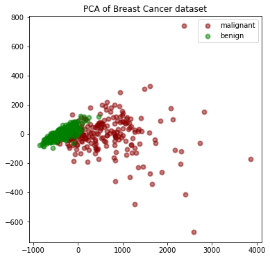

```python
colors = ['darkred', 'green']
lw = 2
fig, axs = plt.subplots(nrows=1, ncols=1, figsize=(6,6))

# gráfico de los datos reducidos con PCA:
for color, i, target_name in zip(colors, [0, 1], target_names):
    axs.scatter(X_r_PCA[y == i, 0], X_r_PCA[y == i, 1], color=color, alpha=.5, lw=lw, label=target_name)
axs.legend(loc='best', shadow=False, scatterpoints=1)
axs.set_title('PCA of Breast Cancer dataset')
```

**Análisis:** comenta el resultado.

**Pregunta:** ¿qué otro método o métodos de reducción de dimensionalidad se podrían aplicar?

**Solución:** t-SNE, LDA,...

**Ejercicio:** elige un método de reducción y genera el gráfico (2D) con el resultado.

**Solución:**

```
dimensions de les dades reduïdes amb t-SNE: (569, 2)
```

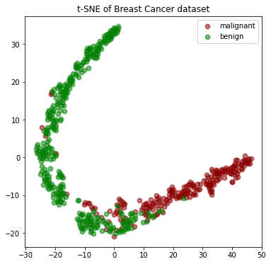

```python
# reducción de la dimensionalidad con t-SNE:
from sklearn.manifold import TSNE
mytsne = TSNE(n_components=2)
X_r_TSNE = mytsne.fit_transform(X)
print("dimensions de les dades reduïdes amb t-SNE:", np.shape(X_r_TSNE))

# gráfico de los datos reducidos con t-SNE:
fig, axs = plt.subplots(nrows=1, ncols=1, figsize=(6,6))
for color, i, target_name in zip(colors, [0, 1], target_names):
    axs.scatter(X_r_TSNE[y == i, 0], X_r_TSNE[y == i, 1], color=color, alpha=.5, lw=lw, label=target_name)
axs.legend(loc='best', shadow=False, scatterpoints=1)
axs.set_title('t-SNE of Breast Cancer dataset');
```

```
Dimensions de les dades reduïdes amb LDA: (569, 2)
```

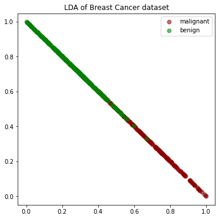

```python
# reducción de la dimensionalidad con LDA:
from sklearn.decomposition import LatentDirichletAllocation as LDA
lda = LDA(n_components=2, n_jobs=-1)
X_r_LDA = lda.fit(X).transform(X)
print("Dimensions de les dades reduïdes amb LDA:", np.shape(X_r_LDA))

# gráfico de los datos reducidos con LDA:
fig, axs = plt.subplots(nrows=1, ncols=1, figsize=(6,6))
for color, i, target_name in zip(colors, [0, 1], target_names):
    axs.scatter(X_r_LDA[y == i, 0], X_r_LDA[y == i, 1], color=color, alpha=.5, lw=lw, label=target_name)
axs.legend(loc='best', shadow=False, scatterpoints=1)
axs.set_title('LDA of Breast Cancer dataset');
```

**Análisis:** en comparación con el PCA, ¿qué método ha resultado más efectivo para visualizar las dos clases de diagnóstico de forma separada? ¿Cuándo es más apropriado usar PCA o el otro método elegido?

# 4. Entrenamiento y test (3 puntos)

En este último ejercicio se trata de aplicar un método de aprendizaje supervisado, concretamente el clasificador Decision Tree (un árbol de decisión), para predecir el diagnóstico de cáncer de mama (tumor benigno o maligno) y evaluar la precisión obtenida con el modelo. Para ello usaremos:

- El conjunto de datos original con todos los atributos
- El conjunto de datos reducido a sólo 2 atributos con PCA
- El conjunto de datos sin las variables fuertemente correlacionada y reducido a sólo 2 atributos con el método PCA

**Ejercicio:** usando el conjunto de datos original: - Dividid el dataset en train y test. - Definid un modelo Decision Tree (fijando max_depth = 5 para mantener el modelo simple). - Aplicad validación cruzada con el modelo definido y el dataset de train (con cv=5 ya es suficiente). - Calculad la media y la desviación estándar de la validación cruzada.

Sugerencia: Para separar entre train y test podéis usar train_test_split de sklearn. Sugerencia: Para entrenar un modelo decision tree podéis usar 'DecisionTreeClassifier' de sklearn. Sugerencia: Para aplicar validación cruzada podéis usar 'cross_val_score' de sklearn.

**Solución:**

```python
X_train, X_test, y_train, y_test = train_test_split(X, y, test_size = 0.3, random_state = 100)
clf = DecisionTreeClassifier(max_depth = 5, random_state = 100)
data_scores = cross_val_score(clf, X, y, cv=5)

mean_data = np.mean(data_scores)
std_data = np.std(data_scores)
print('[ORIGINAL DATA] mean: {:.3f}, std: {:.3f}, 1std score range: {:.2f} - {:.2f}'.format(mean_data,
                                                                                            std_data,
                                                                                            mean_data - std_data,
                                                                                            mean_data + std_data))
```

```
[ORIGINAL DATA] mean: 0.924, std: 0.018, 1std score range: 0.91 - 0.94
```

**Ejercicio:** haced el fit con todo el conjunto de train, y generad el árbol de decisión correspondiente.

Sugerencia: para dibujar árboles de decisión, echad un ojo a este link: https://towardsdatascience.com/visualizing-decision-trees-with-python-scikit-learn-graphviz-matplotlib-1c50b4aa68dc

**Solución:**

```python
def plot_decision_tree(clf, fn):
    cn=['0', '1', '2']

    dot_data = StringIO()
    export_graphviz(clf,
                    feature_names = fn,
                    class_names=cn,
                    out_file=dot_data,
                    filled=True, rounded=True,
                    special_characters=True)
    graph = pydotplus.graph_from_dot_data(dot_data.getvalue())
    return Image(graph.create_png())
```

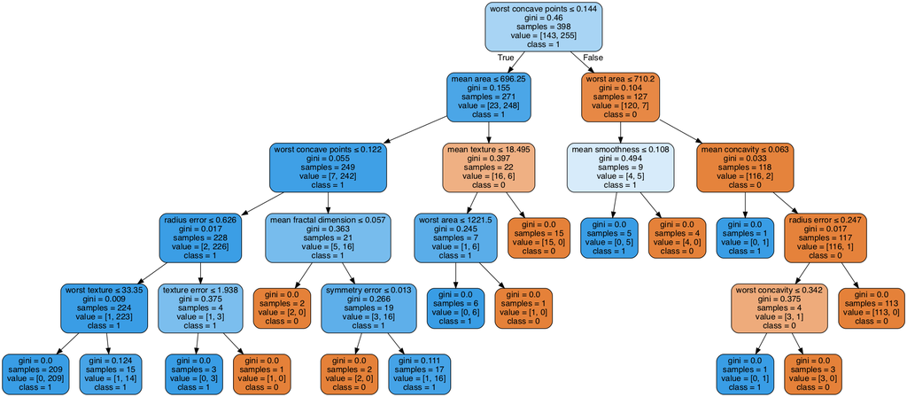

```python
fn=upper.columns[:-1]
clf.fit(X_train, y_train)
plot_decision_tree(clf, fn)
```

**Ejercicio:** repetid el mismo procedimiento que en el ejercicio anterior con el dataset reducido a 2 dimensiones con PCA.

**Solución:**

```python
X_train, X_test, y_train, y_test = train_test_split(X_r_PCA, y, test_size = 0.3, random_state = 100)
clf = DecisionTreeClassifier(max_depth = 5, random_state = 100)
pca_scores = cross_val_score(clf, X_r_PCA, y, cv=5)

mean_pca = np.mean(pca_scores)
std_pca = np.std(pca_scores)
print('[PCA] mean: {:.3f}, std: {:.3f}, 1std score range: {:.2f} - {:.2f}'.format(mean_pca,
                                                                                  std_pca,
                                                                                  mean_pca - std_pca,
                                                                                  mean_pca + std_pca))
```

```
[PCA] mean: 0.903, std: 0.009, 1std score range: 0.89 - 0.91
```

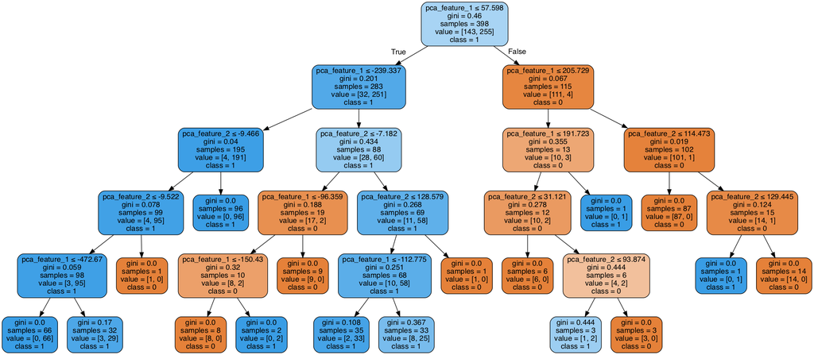

```python
fn = ['pca_feature_1', 'pca_feature_2']
clf.fit(X_train, y_train)
plot_decision_tree(clf, fn)
```

**Ejercicio:** repetid el mismo procedimiento que en el ejercicio anterior con el conjunto de datos sin las variables fuertemente correlacionada y reducido a sólo 2 atributos con el método PCA.

**Solución:**

```python
X_train, X_test, y_train, y_test = train_test_split(X_r_PCA_red, y, test_size = 0.3, random_state = 100)
clf = DecisionTreeClassifier(max_depth = 5, random_state = 100)
pca_scores = cross_val_score(clf, X_r_PCA_red, y, cv=5)

mean_pca = np.mean(pca_scores)
std_pca = np.std(pca_scores)
print('[PCA] mean: {:.3f}, std: {:.3f}, 1std score range: {:.2f} - {:.2f}'.format(mean_pca,
                                                                                  std_pca,
                                                                                  mean_pca - std_pca,
                                                                                  mean_pca + std_pca))
```

```
[PCA] mean: 0.856, std: 0.030, 1std score range: 0.83 - 0.89
```

[figure not shown]

```python
fn = ['tsne_feature_1', 'tsne_feature_2']
clf.fit(X_train, y_train)
plot_decision_tree(clf, fn)
```

**Análisis:** ¿con qué datos ha funcionado mejor? ¿Tiene sentido? ¿Cuadra con los resultados que hemos visto en el ejercicio 3?

**Solución:** Con los tres modelos obtenemos resultados similares. Los tres consiguen clasificar muy bien el tipo de cáncer. Esto tiene sentido, puesto que en el ejercicio anterior hemos visto que la reducción de dimensionalidad conseguía separar muy bien las clases. Podría matizarse que con el conjunto de datos reducido el resultado es algo peor, tiene sentido ya que se están eliminando atributos potencialmente útiles para discernir si el cáncer es benigno o maligno.

**Ejercicio:** con el mejor modelo que hayáis obtenido: - Generad predicciones sobre el dataset de test. - Calculad la precisión de las predicciones obtenidas y la matriz de confusión asociada.

Sugerencia: para calcular la precisión y la matriz de confusión podéis usar las funciones dentro del módulo "metrics" de sklearn.

**Solución:**

```python
X_train, X_test, y_train, y_test = train_test_split(X, y, test_size = 0.3, random_state = 100)
clf = DecisionTreeClassifier(max_depth = 5, random_state = 100)
clf.fit(X_train, y_train)

y_pred_ori = clf.predict(X_test)

print("Original dataset - accuracy:\n", accuracy_score(y_test, y_pred_ori))
print("Original dataset - confusion matrix:\n", confusion_matrix(y_test, y_pred_ori))
```

```
Original dataset - accuracy:
 0.9415204678362573
Original dataset - confusion matrix:
 [[62  7]
 [ 3 99]]
```